# IE360 Homework 1

Ugur Kumcu

2022-04-07

## 1 - INTRODUCTION

First of all, I must state that I wanted to examine the change in the price of people’s basic needs over the years. I thought to examine the food-related ones, which are at the top of these basic needs. Then I wondered about the relationship between the Turkish stock market and the increase in these basic needs. That’s why I used 4 different data from https://evds2.tcmb.gov.tr/ and https://trends.google.com/trends/.

Names of these data:

- Bist100
- CPI for non-alcoholic food
- Credit Card Total Expenditure Amount for Various Food
- Search for “Food Prices”

The question I am really curious about is this: **How much is the increase in food prices and expenditures correlated with the CPI? Has the return of the Turkish stock market (Bist100) been able to cover this increase in food prices?** In order to get the answers to these questions, I will look at the monthly data between 2015 and 2022. I will plot different types of graphs for every data individually.

### Used Packages

```r
library(zoo,warn.conflicts = FALSE)
library(readxl)
library(ggplot2)
library(lubridate)
library(corrplot)
```

I get all the data related to the answer to my question from the sites I specified and assign them to the variables.

```r
Bist <- read_excel("Bist.xlsx")
VariousFood <- read_excel("VariousFood.xlsx")
CPI <- read_excel("CPI.xlsx")
FoodSearch <- read.csv("FoodSearch.csv")
```

I changed the data type of the date parts to use the data better.

```r
Bist$Date <- as.yearmon(Bist$Date)
VariousFood$Date <- as.yearmon(VariousFood$Date)
CPI$Date <- as.yearmon(CPI$Date)
FoodSearch$Date <- as.yearmon(FoodSearch$Date)
```

## 2 - Bist100 Closing Prices (2015-2022) Monthly

### 2.1 - General Summary

```r
summary(Bist$Closing_Price)
```

```
##    Min. 1st Qu.  Median    Mean 3rd Qu.    Max.
##   717.3   841.5   999.6  1045.0  1145.2  2003.2
```

```r
## Unit is Turkish Lira
```

```r
head(Bist, 12)
```

```
## # A tibble: 12 x 2
##    Date      Closing_Price
##    <yearmon>         <dbl>
##  1 Oca 2015           889.
##  2 Şub 2015           841.
##  3 Mar 2015           808.
##  4 Nis 2015           839.
##  5 May 2015           830.
##  6 Haz 2015           822.
##  7 Tem 2015           799.
##  8 Ağu 2015           752.
##  9 Eyl 2015           742.
## 10 Eki 2015           794.
## 11 Kas 2015           752.
## 12 Ara 2015           717.
```

```r
## First Year Data
```

```r
tail(Bist, 12)
```

```
## # A tibble: 12 x 2
##    Date      Closing_Price
##    <yearmon>         <dbl>
##  1 Şub 2021          1471.
##  2 Mar 2021          1392.
##  3 Nis 2021          1398.
##  4 May 2021          1420.
##  5 Haz 2021          1356.
##  6 Tem 2021          1393.
##  7 Ağu 2021          1472.
##  8 Eyl 2021          1406.
##  9 Eki 2021          1522.
## 10 Kas 2021          1810.
## 11 Ara 2021          1858.
## 12 Oca 2022          2003.
```

```r
## Last Year Data
```

### 2.2 - Plotted Data

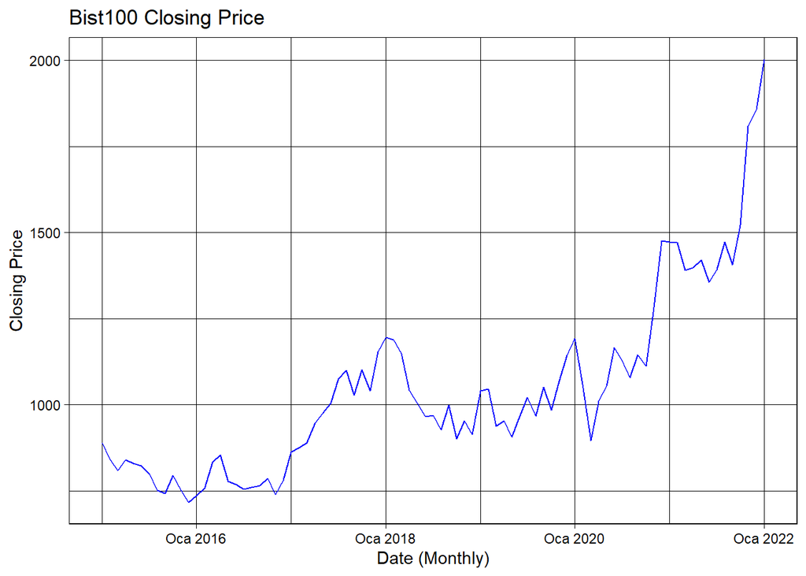

```r
ggplot(Bist, aes(Date, Closing_Price)) +
geom_line(data = Bist, color="blue", linetype = "solid") +
ggtitle("Bist100 Closing Price") +
xlab("Date (Monthly)") +
ylab("Closing Price") +
theme_linedraw()
```

```r
## Data Plotting
```

### 2.3 - Box-Plotted Data

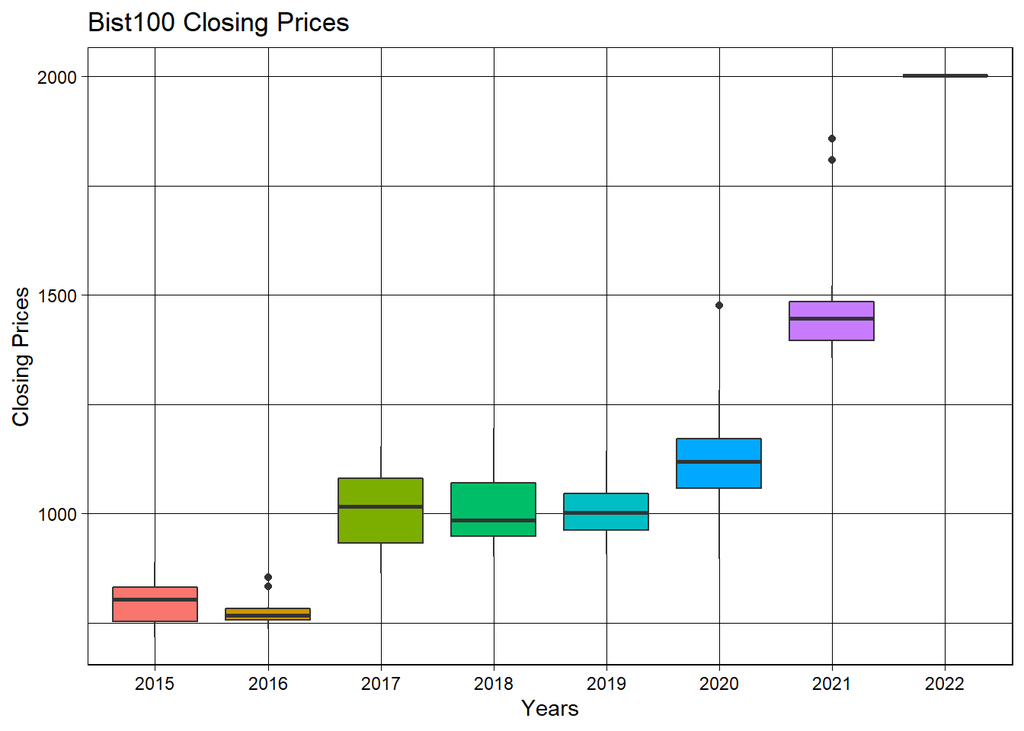

```r
ggplot(Bist, aes(x=factor(year(Date)),y=Closing_Price)) +
geom_boxplot(aes(fill=factor(year(Date)))) +
xlab("Years") + ylab("Closing Prices") +
ggtitle("Bist100 Closing Prices") +
theme_linedraw() + theme(legend.position = "none")
```

### 2.4 - Histogram Data

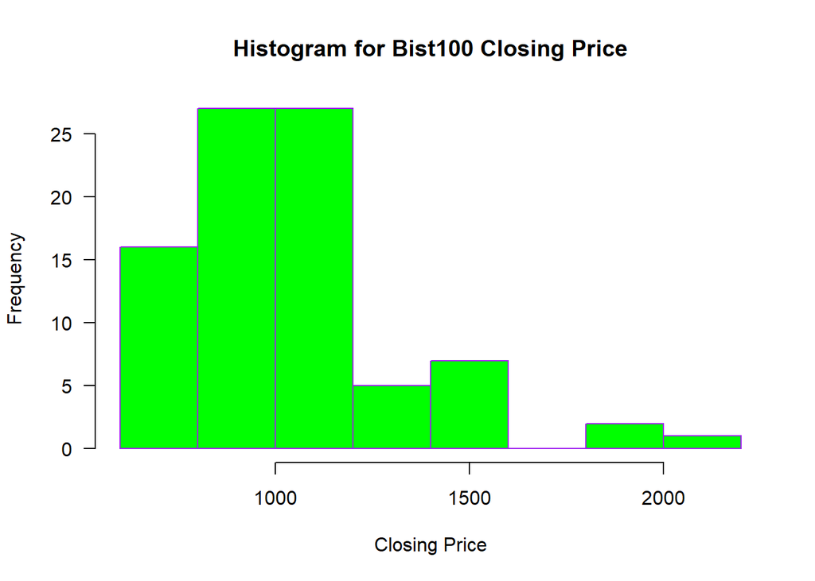

```r
hist(Bist$Closing_Price,
     main="Histogram for Bist100 Closing Price",
     xlab="Closing Price",
     border="purple",
     col="green",
     las=1,
     breaks=5)
```

## 3 - Total Expenditure Amount for Various Food (2015-2022) Monthly

### 3.1 - General Summary

```r
summary(VariousFood$Total_Expenditure)
```

```
##     Min.  1st Qu.   Median     Mean  3rd Qu.     Max.
##  2291403  3321022  4238767  5081261  6082906 14778159
```

```r
## (Thousand TRY)
```

```r
head(VariousFood, 12)
```

```
## # A tibble: 12 x 2
##    Date      Total_Expenditure
##    <yearmon>             <dbl>
##  1 Oca 2015            2773727
##  2 Şub 2015            2291403
##  3 Mar 2015            2492968
##  4 Nis 2015            2581193
##  5 May 2015            3321022
##  6 Haz 2015            2607654
##  7 Tem 2015            3159310
##  8 Ağu 2015            2539130
##  9 Eyl 2015            2446692
## 10 Eki 2015            3002337
## 11 Kas 2015            2440278
## 12 Ara 2015            2503390
```

```r
## First Year Data
```

```r
tail(VariousFood, 12)
```

```
## # A tibble: 12 x 2
##    Date      Total_Expenditure
##    <yearmon>             <dbl>
##  1 Şub 2021            7208208
##  2 Mar 2021            7796128
##  3 Nis 2021            9878024
##  4 May 2021            7963546
##  5 Haz 2021            9021663
##  6 Tem 2021           11638389
##  7 Ağu 2021            9302503
##  8 Eyl 2021           11957277
##  9 Eki 2021           12585735
## 10 Kas 2021           10787753
## 11 Ara 2021           14778159
## 12 Oca 2022           11008659
```

```r
## Last Year Data
```

### 3.2 - Plotted Data

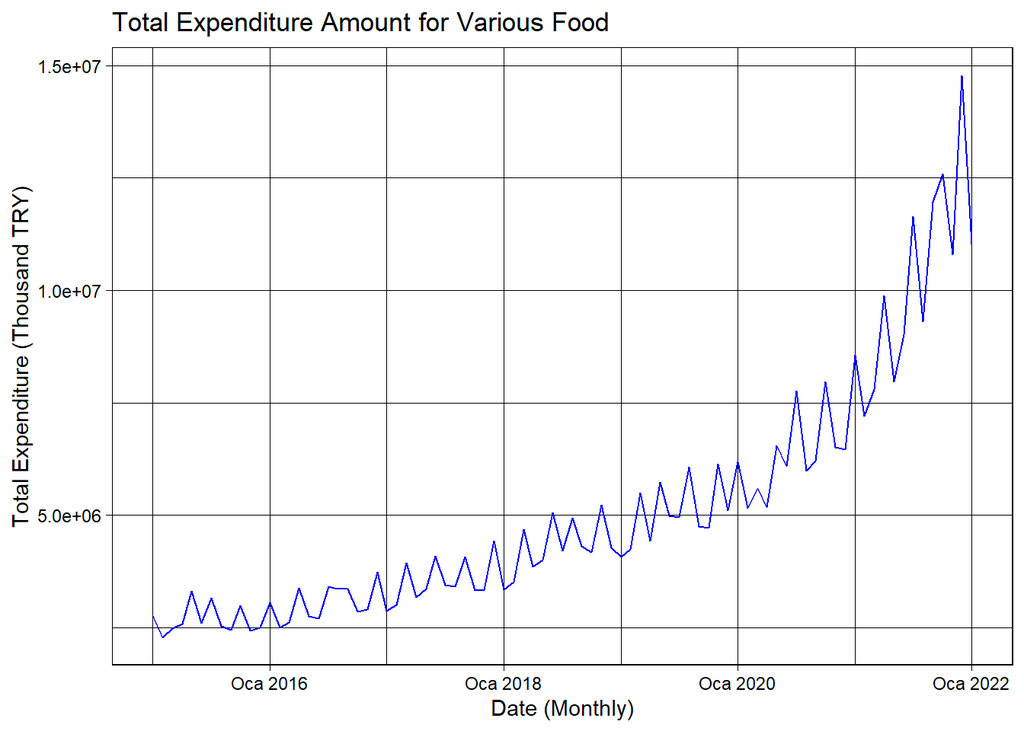

```r
ggplot(VariousFood, aes(Date, Total_Expenditure)) +
geom_line(data = VariousFood, color="blue", linetype = "solid") +
ggtitle("Total Expenditure Amount for Various Food") +
xlab("Date (Monthly)") +
ylab("Total Expenditure (Thousand TRY)") +
theme_linedraw()
```

```r
## Data Plotting
```

### 3.3 - Box-Plotted Data

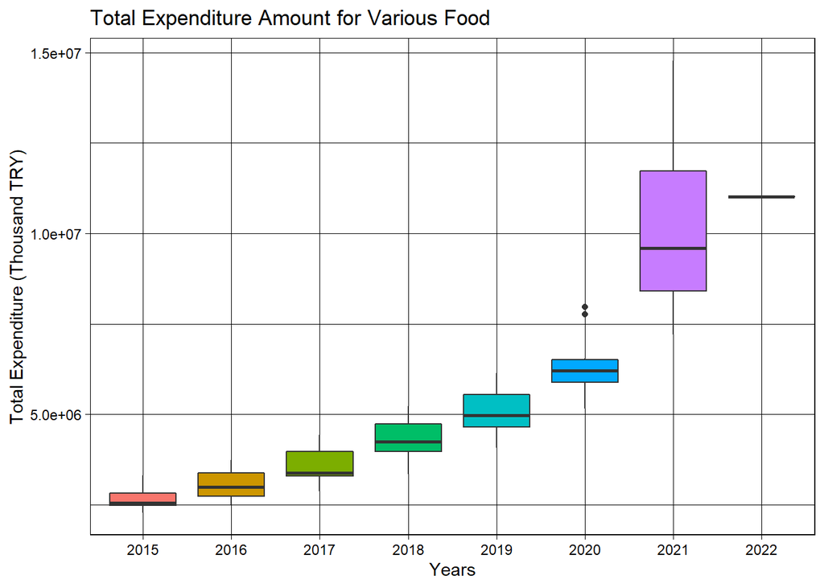

```r
ggplot(VariousFood, aes(x=factor(year(Date)),y=Total_Expenditure)) +
geom_boxplot(aes(fill=factor(year(Date)))) +
xlab("Years") + ylab("Total Expenditure (Thousand TRY)") +
ggtitle("Total Expenditure Amount for Various Food") +
theme_linedraw() + theme(legend.position = "none")
```

### 3.4 - Histogram Data

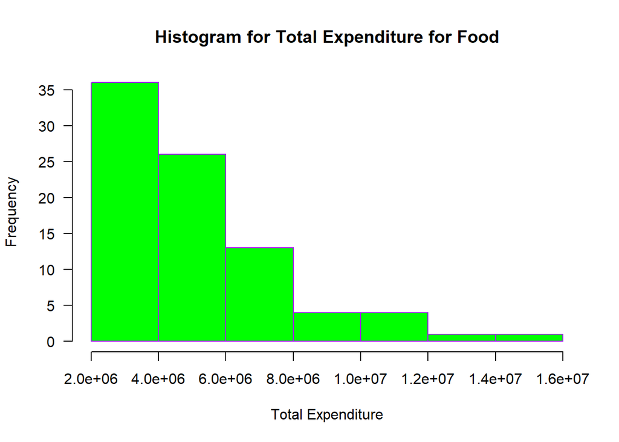

```r
hist(VariousFood$Total_Expenditure,
     main="Histogram for Total Expenditure for Food",
     xlab="Total Expenditure",
     border="purple",
     col="green",
     las=1,
     breaks=5)
```

## 4 - CPI for Food and non-alcoholic Beverages (2015-2022) Monthly

### 4.1 - General Summary

In the calculation of this data, a basket of food and non-alcoholic beverages that people consume monthly is created. This basket could be bought for 100 TL in 2003. This data is the data of how much this basket costs according to the months. Note: The contents of the basket and their weights have been rearranged by law.

```r
summary(CPI$CPI)
```

```
##    Min. 1st Qu.  Median    Mean 3rd Qu.    Max.
##   282.2   315.1   412.6   450.9   549.5   969.7
```

```r
## (Unit is Turkish Lira)
```

```r
head(CPI, 12)
```

```
## # A tibble: 12 x 2
##    Date        CPI
##    <yearmon> <dbl>
##  1 Oca 2015   282.
##  2 Şub 2015   290.
##  3 Mar 2015   297.
##  4 Nis 2015   302.
##  5 May 2015   293.
##  6 Haz 2015   285.
##  7 Tem 2015   286.
##  8 Ağu 2015   290.
##  9 Eyl 2015   293.
## 10 Eki 2015   296.
## 11 Kas 2015   299.
## 12 Ara 2015   302.
```

```r
## First Year Data
```

```r
tail(CPI, 12)
```

```
## # A tibble: 12 x 2
##    Date        CPI
##    <yearmon> <dbl>
##  1 Şub 2021   639.
##  2 Mar 2021   646.
##  3 Nis 2021   660.
##  4 May 2021   662.
##  5 Haz 2021   668.
##  6 Tem 2021   686.
##  7 Ağu 2021   708.
##  8 Eyl 2021   712.
##  9 Eki 2021   725.
## 10 Kas 2021   754.
## 11 Ara 2021   874.
## 12 Oca 2022   970.
```

```r
## Last Year Data
```

### 4.2 - Plotted Data

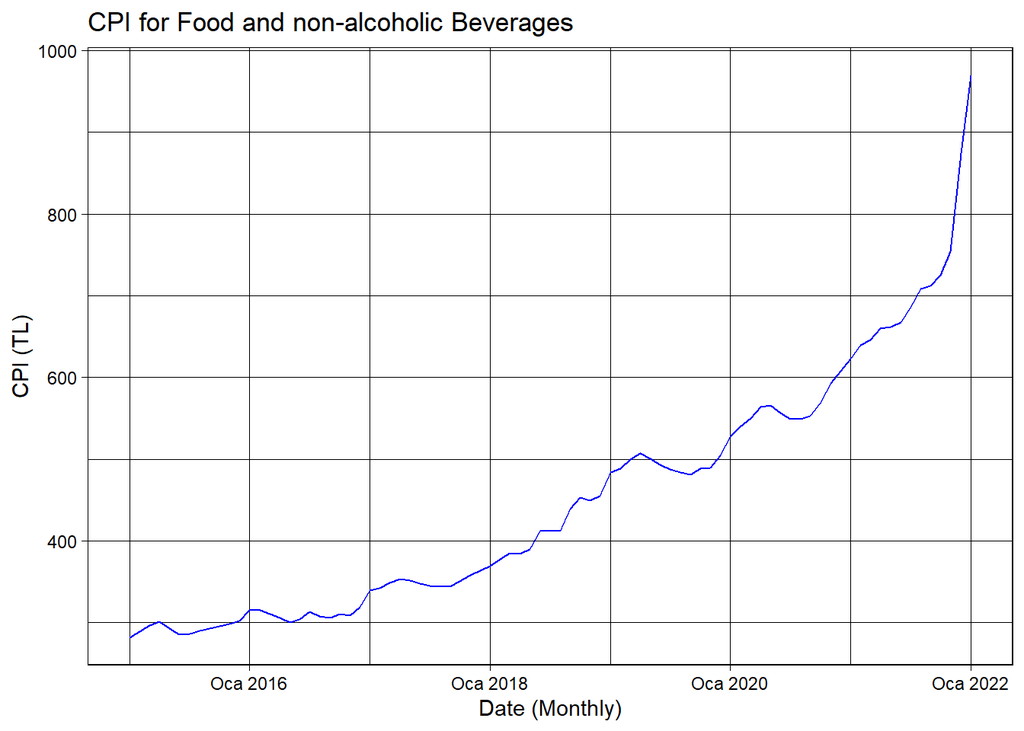

```r
ggplot(CPI, aes(Date, CPI)) +
geom_line(data = CPI, color="blue", linetype = "solid") +
ggtitle("CPI for Food and non-alcoholic Beverages") +
xlab("Date (Monthly)") +
ylab("CPI (TL)") +
theme_linedraw()
```

```r
## Data Plotting
```

### 4.3 - Box-Plotted Data

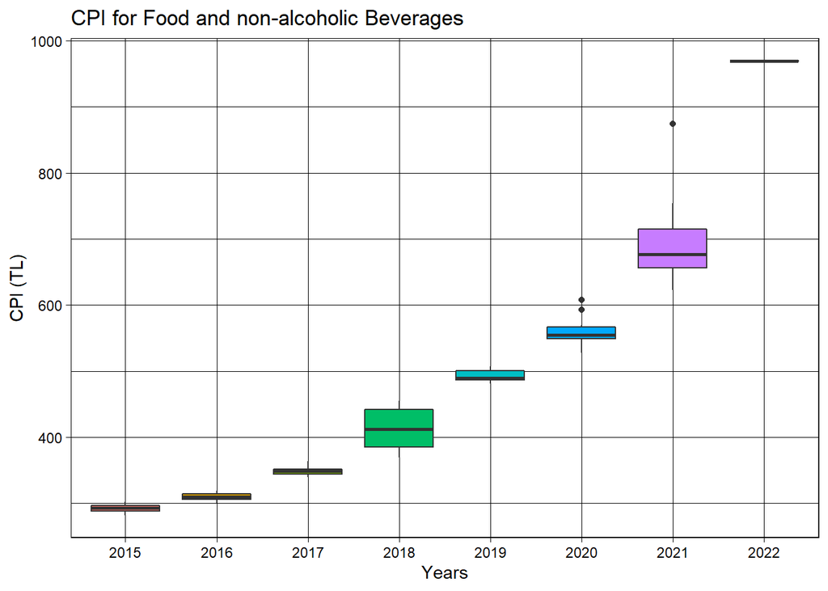

```r
ggplot(CPI, aes(x=factor(year(Date)),y=CPI)) +
geom_boxplot(aes(fill=factor(year(Date)))) +
xlab("Years") + ylab("CPI (TL)") +
ggtitle("CPI for Food and non-alcoholic Beverages") +
theme_linedraw() + theme(legend.position = "none")
```

### 4.4 - Histogram Data

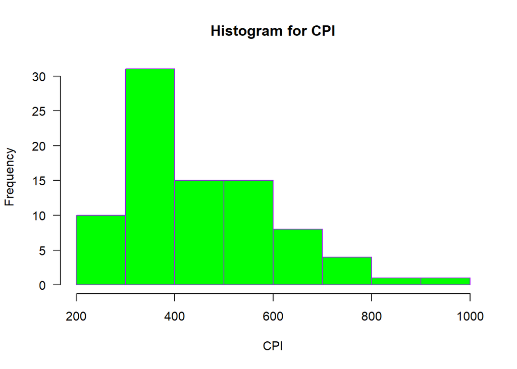

```r
hist(CPI$CPI,
     main="Histogram for CPI",
     xlab="CPI",
     border="purple",
     col="green",
     las=1,
     breaks=5)
```

## 5 - Google Trends Result for “Gıda Fiyatları” (2015-2022) Monthly

### 5.1 - General Summary

```r
summary(FoodSearch$Index)
```

```
##    Min. 1st Qu.  Median    Mean 3rd Qu.    Max.
##   30.00   38.00   42.00   44.93   49.00  100.00
```

```r
head(FoodSearch, 12)
```

```
##        Date Index
## 1  Oca 2015    37
## 2  Şub 2015    51
## 3  Mar 2015    40
## 4  Nis 2015    38
## 5  May 2015    35
## 6  Haz 2015    43
## 7  Tem 2015    36
## 8  Ağu 2015    34
## 9  Eyl 2015    34
## 10 Eki 2015    35
## 11 Kas 2015    36
## 12 Ara 2015    34
```

```r
## First Year Data
```

```r
tail(FoodSearch, 12)
```

```
##        Date Index
## 74 Şub 2021    52
## 75 Mar 2021    52
## 76 Nis 2021    53
## 77 May 2021    44
## 78 Haz 2021    40
## 79 Tem 2021    42
## 80 Ağu 2021    55
## 81 Eyl 2021    61
## 82 Eki 2021    64
## 83 Kas 2021    74
## 84 Ara 2021   100
## 85 Oca 2022    65
```

```r
## Last Year Data
```

### 5.2 - Plotted Data

[figure not shown]

```r
ggplot(FoodSearch, aes(Date, Index)) +
geom_line(data = FoodSearch, color="blue", linetype = "solid") +
ggtitle("Google Trends Results for 'Gıda Fiyatları'") +
xlab("Date (Monthly)") +
ylab("Index") +
theme_linedraw()
```

```r
## Data Plotting
```

### 5.3 - Box-Plotted Data

[figure not shown]

```r
ggplot(FoodSearch, aes(x=factor(year(Date)),y=Index)) +
geom_boxplot(aes(fill=factor(year(Date)))) +
xlab("Years") + ylab("Index") +
ggtitle("Google Trends Results for 'Gıda Fiyatları'") +
theme_linedraw() + theme(legend.position = "none")
```

### 5.4 - Histogram Data

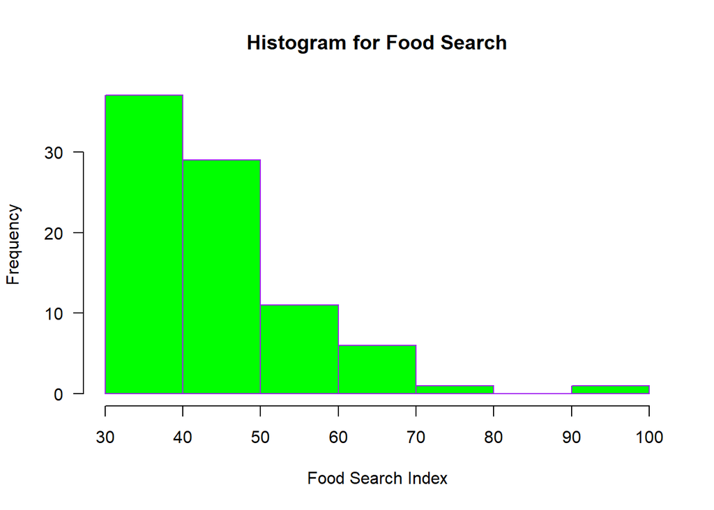

```r
hist(FoodSearch$Index,
     main="Histogram for Food Search",
     xlab="Food Search Index",
     border="purple",
     col="green",
     las=1,
     breaks=5)
```

## 6 - CORRELATION MATRIX

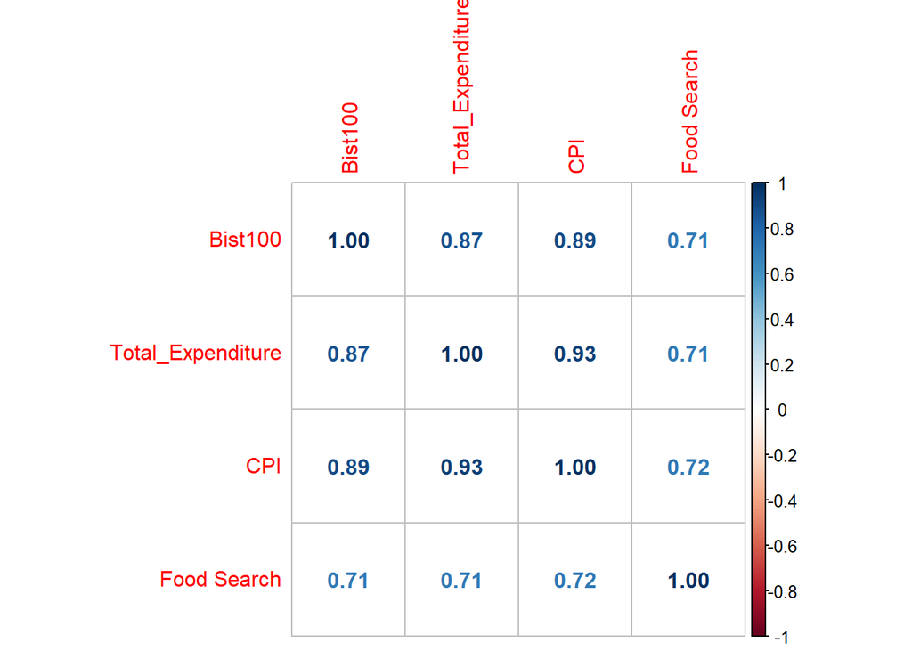

```r
data <- data.frame( Bist$Closing_Price,  VariousFood$Total_Expenditure, CPI$CPI, FoodSearch$Index)
names(data) <- c("Bist100", "Total_Expenditure", "CPI" , "Food Search")
data_correlation = cor(data)
corrplot(data_correlation, method="number")
```

## 7 - CONCLUSION

At the beginning of my report, I tried to sketch all the related graphs individually in order to understand the data without using any mathematical formula. After sketching, I saw strong relationship between graphs. That’s why I used correlation matrix at the end of my report.

First of all, the Bist100 closing price seems increasing exponentially. I have listed first year and the last year data, the last year data is steeper than the first year data. I also summarized the data and checked min, max and mean values.

Secondly, I draw all the data related to food prices(CPI), expenditure and food searches. Additionally, checked their summaries and saw that all of them seems so related.

Lastly, I used corrplot function to understand level of the relationship between those data. All of the four data is strongly related based on corelation matrix because their correlation rate is higher that 0.70 but I expected more relationship between CPI and Total Expenditure Amount because the first one is calculated based on the second one. I think the main reason behind this result is changing the weights of foods in the basket.

In conclusion, Those data are highly correlated each other and increasing exponentially.